# Vorhersage der Schwere eines Unfalls in Frankreich

Idee dieses Projektes ist, Voraussagen über den Ausgang eines Vehrsunfalls in Frankreich treffen zu können. Die Labels sind also 1:' Unharmed' 2: 'Killed', 3: 'Injured hospitalized', 4: 'Slightly injured'.  
Wir benutzen hier franzöische Daten, weil die Unfälle in unserem Nachbarland sehr genau erfasst werden (siehe sazu weiter unten unsere Erklärung der einzelnen Features). Beispielsweise werden neben dem Alter und dem Geschlecht auch Fahrzeugkategorie und bis zu drei Sicherheitsausrüstungen(bspw. Helm bei Motorradfahrern oder Gürtel beim Auto oder Bus) genannt und sogar die Entfernung zum nächten Nottelefon auf der Autobahn. Die Anzahl der Features (über 40) läst uns gute Voraussagen treffen.

## Pakete einbinden

```python
import numpy as np
import pandas as pd

import seaborn as sns
import matplotlib.pyplot as plt
import matplotlib as mpl

plt.rcParams['figure.figsize'] = [12, 8]
plt.rcParams['figure.dpi'] = 120

import warnings
warnings.filterwarnings('ignore')
```

# Daten einlesen und übersetzen

Der Datensatz liegt in vier Tabellen vor, die einzeln eingelesen werden. Die Spalten werden übersetzt.

```python
characteristics = pd.read_csv('caracteristiques-2019.csv')
characteristics.rename(columns={'Num_Acc': 'ID_Acc', 'jour': 'Day', 'mois': 'Month', 'an': 'Year', 'hrmn': 'Time', 'lum': 'Light', 'dep': 'Department','com': 'Municipality','agg': 'Location'}, inplace=True)

places = pd.read_csv('lieux-2019.csv')
places.rename(columns={'Num_Acc': 'ID_Acc', "catr": "road_cat", "voie": "route_num", "v1": "road_index1", "v2": "road_index2", "circ": "traffic_regime", "nbv": "traffic_lanes", "vosp": "reserved_lane","pr":"upstream_terminal","pr1":"distance_to_upstream", "lartpc": "central_reservation_width", "larrout": "roadwidth_vehicles", "vma": "speed_limit"}, inplace=True)

drivers = pd.read_csv('usagers-2019.csv')
drivers.rename(columns={'Num_Acc': 'ID_Acc', 'id_vehicule': 'ID_veh', 'num_veh': 'Vehicle_No', 'catu': 'User_category', 'grav': 'Severity', 'sexe': 'Gender_driver', 'an_nais': 'DOB_driver','trajet': 'Reason_for_travel','secu1': 'Safety_equip_1','secu2': 'Safety_equip_2','secu3': 'Safety_equip_3', 'locp': 'Ped_loc', 'actp': 'Ped_act', 'etatp': 'Ped_acc'}, inplace=True)

vehicles = pd.read_csv('vehicules-2019.csv')
vehicles.rename(columns={'Num_Acc': 'ID_Acc', 'id_vehicule': 'ID_veh', 'num_veh': 'Vehicle_No', 'catv': 'Vehicle_category', 'obs': 'Fix_Obst_st', 'obsm': 'Mov_Obst_st', 'choc': 'Shock_pt','manv': 'Maneuver','occutc': 'No.of_occupants', 'senc': 'Flow_Direction'}, inplace=True)


characteristics = characteristics.set_index('ID_Acc')
places = places.set_index('ID_Acc')
drivers = drivers.set_index('ID_veh')
vehicles = vehicles.set_index('ID_veh')
```

```python
characteristics
```

| ID_Acc | Day | Month | Year | Time | Light | Department | Municipality | Location | int | atm | col | adr | lat | long |
| --- | --- | --- | --- | --- | --- | --- | --- | --- | --- | --- | --- | --- | --- | --- |
| 201900000001 | 30.0 | 11.0 | 2019.0 | 0.062500 | 4.0 | 93 | 93053 | 1.0 | 1.0 | 1.0 | 2.0 | AUTOROUTE A3 | 488962100.0 | 24701200.0 |
| 201900000002 | 30.0 | 11.0 | 2019.0 | 0.118056 | 3.0 | 93 | 93066 | 1.0 | 1.0 | 1.0 | 6.0 | AUTOROUTE A1 | 489307000.0 | 23688000.0 |
| 201900000003 | 28.0 | 11.0 | 2019.0 | 0.635417 | 1.0 | 92 | 92036 | 1.0 | 1.0 | 1.0 | 4.0 | AUTOROUTE A86 | 489358718.0 | 23191744.0 |
| 201900000004 | 30.0 | 11.0 | 2019.0 | 0.847222 | 5.0 | 94 | 94069 | 1.0 | 1.0 | 1.0 | 4.0 | A4 | 488173295.0 | 24281502.0 |
| 201900000005 | 30.0 | 11.0 | 2019.0 | 0.166667 | 3.0 | 94 | 94028 | 1.0 | 1.0 | 1.0 | 2.0 | A86 INT | 487763620.0 | 24332540.0 |
| ... | ... | ... | ... | ... | ... | ... | ... | ... | ... | ... | ... | ... | ... | ... |
| 201900058836 | 30.0 | 11.0 | 2019.0 | 0.375000 | 1.0 | 69 | 69288 | 1.0 | 1.0 | 5.0 | 2.0 | A43 13.029 A 15.971 | 456666600.0 | 50561200.0 |
| 201900058837 | 27.0 | 11.0 | 2019.0 | 0.326389 | 1.0 | 67 | 67482 | 1.0 | 1.0 | 8.0 | 4.0 | Autoroute A.35 | 485769000.0 | 77269000.0 |
| 201900058838 | 30.0 | 11.0 | 2019.0 | 0.111806 | 4.0 | 94 | 94021 | 1.0 | 1.0 | 1.0 | 6.0 | AUTOROUTE A6A | 487717000.0 | 23457600.0 |
| 201900058839 | 30.0 | 11.0 | 2019.0 | 0.638889 | 1.0 | 78 | 78640 | 1.0 | 1.0 | 1.0 | 7.0 | A86 EXT | 487772890.0 | 22237590.0 |
| 201900058840 | 29.0 | 11.0 | 2019.0 | 0.868056 | 3.0 | 92 | 92047 | 1.0 | 1.0 | 1.0 | 2.0 | A13 | 488351236.0 | 21751101.0 |

58840 rows × 14 columns

```python
places
```

| ID_Acc | road_cat | route_num | road_index1 | road_index2 | traffic_regime | traffic_lanes | reserved_lane | prof | upstream_terminal | distance_to_upstream | plan | central_reservation_width | roadwidth_vehicles | surf | infra | situ | speed_limit |
| --- | --- | --- | --- | --- | --- | --- | --- | --- | --- | --- | --- | --- | --- | --- | --- | --- | --- |
| 201900000001 | 1.0 | 3 | 0.0 | NaN | 3.0 | 10.0 | 0.0 | 1.0 | 6.0 | 900.0 | 2.0 | NaN | NaN | 1.0 | 2.0 | 1.0 | 70.0 |
| 201900000002 | 1.0 | 1 | 0.0 | NaN | 1.0 | 2.0 | 0.0 | 4.0 | 3.0 | 845.0 | 2.0 | NaN | NaN | 1.0 | 0.0 | 1.0 | 70.0 |
| 201900000003 | 1.0 | 86 | 0.0 | NaN | 3.0 | 8.0 | 0.0 | 1.0 | 10.0 | 500.0 | 3.0 | NaN | NaN | 1.0 | 0.0 | 1.0 | 90.0 |
| 201900000004 | 1.0 | 4 | 0.0 | NaN | 3.0 | 5.0 | 0.0 | 1.0 | 2.0 | 299.0 | 1.0 | NaN | NaN | 1.0 | 0.0 | 1.0 | 90.0 |
| 201900000005 | 1.0 | 86 | 0.0 | INT | 1.0 | 3.0 | 0.0 | 1.0 | 41.0 | 0.0 | 3.0 | NaN | NaN | 1.0 | 2.0 | 1.0 | 90.0 |
| ... | ... | ... | ... | ... | ... | ... | ... | ... | ... | ... | ... | ... | ... | ... | ... | ... | ... |
| 201900058836 | 1.0 | 43 | 0.0 | NaN | 1.0 | 3.0 | 0.0 | 1.0 | 15.0 | 500.0 | 1.0 | NaN | NaN | 2.0 | 3.0 | 1.0 | 130.0 |
| 201900058837 | 1.0 | 35 | 0.0 | NaN | 1.0 | 2.0 | 0.0 | 1.0 | 303.0 | 282.0 | 1.0 | NaN | NaN | 2.0 | 0.0 | 1.0 | 90.0 |
| 201900058838 | 1.0 | 6 | 0.0 | A | 3.0 | 3.0 | 0.0 | 1.0 | 5.0 | 199.0 | 1.0 | NaN | NaN | 1.0 | 0.0 | 1.0 | 90.0 |
| 201900058839 | 1.0 | 86 | 0.0 | NaN | 1.0 | 1.0 | 0.0 | 1.0 | 59.0 | 99.0 | 3.0 | NaN | NaN | 1.0 | 0.0 | 1.0 | 50.0 |
| 201900058840 | 1.0 | 13 | 0.0 | NaN | 1.0 | 3.0 | 0.0 | 1.0 | 6.0 | 699.0 | 1.0 | NaN | NaN | 1.0 | 0.0 | 2.0 | 110.0 |

58840 rows × 17 columns

```python
vehicles
```

| ID_veh | ID_Acc | Vehicle_No | Flow_Direction | Vehicle_category | Fix_Obst_st | Mov_Obst_st | Shock_pt | Maneuver | motor | No.of_occupants |
| --- | --- | --- | --- | --- | --- | --- | --- | --- | --- | --- |
| 138 306 524 | 201900000001 | B01 | 2 | 7 | 0 | 2 | 5 | 23 | 1 | NaN |
| 138 306 525 | 201900000001 | A01 | 2 | 17 | 1 | 0 | 3 | 11 | 1 | NaN |
| 138 306 523 | 201900000002 | A01 | 1 | 7 | 4 | 0 | 1 | 0 | 1 | NaN |
| 138 306 520 | 201900000003 | A01 | 1 | 7 | 0 | 2 | 1 | 2 | 1 | NaN |
| 138 306 521 | 201900000003 | B01 | 1 | 7 | 1 | 0 | 4 | 2 | 1 | NaN |
| ... | ... | ... | ... | ... | ... | ... | ... | ... | ... | ... |
| 137 982 135 | 201900058837 | C01 | 1 | 7 | 0 | 2 | 1 | 2 | 1 | NaN |
| 137 982 132 | 201900058838 | A01 | 2 | 7 | 3 | 0 | 1 | 21 | 0 | NaN |
| 137 982 131 | 201900058839 | A01 | 2 | 33 | 0 | 0 | 7 | 1 | 1 | NaN |
| 137 982 129 | 201900058840 | B01 | 1 | 10 | 0 | 2 | 4 | 0 | 2 | NaN |
| 137 982 130 | 201900058840 | A01 | 1 | 10 | 0 | 2 | 1 | 0 | 1 | NaN |

100710 rows × 10 columns

```python
drivers
```

| ID_veh | ID_Acc | Vehicle_No | place | User_category | Severity | Gender_driver | DOB_driver | Reason_for_travel | Safety_equip_1 | Safety_equip_2 | Safety_equip_3 | Ped_loc | Ped_act | Ped_acc |
| --- | --- | --- | --- | --- | --- | --- | --- | --- | --- | --- | --- | --- | --- | --- |
| 138 306 524 | 201900000001 | B01 | 2 | 2 | 4 | 2 | 2002 | 0 | 1 | 0 | -1 | -1 | -1 | -1 |
| 138 306 524 | 201900000001 | B01 | 1 | 1 | 4 | 2 | 1993 | 5 | 1 | 0 | -1 | -1 | -1 | -1 |
| 138 306 525 | 201900000001 | A01 | 1 | 1 | 1 | 1 | 1959 | 0 | 1 | 0 | -1 | -1 | -1 | -1 |
| 138 306 523 | 201900000002 | A01 | 1 | 1 | 4 | 2 | 1994 | 0 | 1 | 0 | -1 | -1 | -1 | -1 |
| 138 306 520 | 201900000003 | A01 | 1 | 1 | 1 | 1 | 1996 | 0 | 1 | 0 | -1 | -1 | 0 | -1 |
| ... | ... | ... | ... | ... | ... | ... | ... | ... | ... | ... | ... | ... | ... | ... |
| 137 982 135 | 201900058837 | C01 | 1 | 1 | 4 | 2 | 1988 | 1 | 1 | 0 | -1 | -1 | -1 | -1 |
| 137 982 132 | 201900058838 | A01 | 1 | 1 | 4 | 1 | 1998 | 9 | 1 | 0 | -1 | -1 | -1 | -1 |
| 137 982 131 | 201900058839 | A01 | 1 | 1 | 3 | 1 | 1979 | 0 | 2 | 0 | -1 | -1 | -1 | -1 |
| 137 982 129 | 201900058840 | B01 | 1 | 1 | 4 | 1 | 1974 | 0 | 1 | 0 | -1 | -1 | 0 | -1 |
| 137 982 130 | 201900058840 | A01 | 1 | 1 | 1 | 1 | 1971 | 0 | 1 | -1 | -1 | 0 | 0 | -1 |

132977 rows × 14 columns

# Datensatz zusammenfügen

Kurze Erklärung, wieso kein einfacher Merge funktioniert: bei den ersten beiden Datzensätzen wird die ID nicht als int64, sondern als object gespeichert, weil sie den vorhanden Speicherplatz für eine "C-long" übersteigt. Deshalb ist auch eine Umwandlung zu diesem dtype nicht möglich. Folgende Fehlermeldung kommt: *Python int too large to convert to C long*. Pandas gleift auf C zurück und dort sind keine so großen Zahlen möglich.

Ein merge ist auf Zeilen mit unterschiedlichen dtypes nicht möglich: *You are trying to merge on object and int64 columns. If you wish to proceed you should use pd.concat*. Wie uns die Fehlermeldung rät, benutzen wir pd.concat.

```python
df_acc = pd.concat([characteristics, places.reindex(characteristics.index)], axis=1)
df_veh = pd.concat([drivers, vehicles.reindex(drivers.index)], axis=1)
```

```python
df_acc = df_acc.loc[:, ~df_acc.columns.duplicated()]
df_veh = df_veh.loc[:, ~df_veh.columns.duplicated()]

df_veh.reset_index(drop=True, inplace=True)

df_veh.index = df_veh['ID_Acc'].astype('str')

df_veh = df_veh.drop(['ID_Acc'], axis=1)

df = pd.concat([df_acc.reindex(df_veh.index), df_veh], axis=1)
```

```python
df
```

| ID_Acc | Day | Month | Year | Time | Light | Department | Municipality | Location | int | atm | ... | Ped_act | Ped_acc | Flow_Direction | Vehicle_category | Fix_Obst_st | Mov_Obst_st | Shock_pt | Maneuver | motor | No.of_occupants |
| --- | --- | --- | --- | --- | --- | --- | --- | --- | --- | --- | --- | --- | --- | --- | --- | --- | --- | --- | --- | --- | --- |
| 201900000001 | 30.0 | 11.0 | 2019.0 | 0.062500 | 4.0 | 93 | 93053 | 1.0 | 1.0 | 1.0 | ... | -1 | -1 | 2 | 7 | 0 | 2 | 5 | 23 | 1 | NaN |
| 201900000001 | 30.0 | 11.0 | 2019.0 | 0.062500 | 4.0 | 93 | 93053 | 1.0 | 1.0 | 1.0 | ... | -1 | -1 | 2 | 7 | 0 | 2 | 5 | 23 | 1 | NaN |
| 201900000001 | 30.0 | 11.0 | 2019.0 | 0.062500 | 4.0 | 93 | 93053 | 1.0 | 1.0 | 1.0 | ... | -1 | -1 | 2 | 17 | 1 | 0 | 3 | 11 | 1 | NaN |
| 201900000002 | 30.0 | 11.0 | 2019.0 | 0.118056 | 3.0 | 93 | 93066 | 1.0 | 1.0 | 1.0 | ... | -1 | -1 | 1 | 7 | 4 | 0 | 1 | 0 | 1 | NaN |
| 201900000003 | 28.0 | 11.0 | 2019.0 | 0.635417 | 1.0 | 92 | 92036 | 1.0 | 1.0 | 1.0 | ... | 0 | -1 | 1 | 7 | 0 | 2 | 1 | 2 | 1 | NaN |
| ... | ... | ... | ... | ... | ... | ... | ... | ... | ... | ... | ... | ... | ... | ... | ... | ... | ... | ... | ... | ... | ... |
| 201900058837 | 27.0 | 11.0 | 2019.0 | 0.326389 | 1.0 | 67 | 67482 | 1.0 | 1.0 | 8.0 | ... | -1 | -1 | 1 | 7 | 0 | 2 | 1 | 2 | 1 | NaN |
| 201900058838 | 30.0 | 11.0 | 2019.0 | 0.111806 | 4.0 | 94 | 94021 | 1.0 | 1.0 | 1.0 | ... | -1 | -1 | 2 | 7 | 3 | 0 | 1 | 21 | 0 | NaN |
| 201900058839 | 30.0 | 11.0 | 2019.0 | 0.638889 | 1.0 | 78 | 78640 | 1.0 | 1.0 | 1.0 | ... | -1 | -1 | 2 | 33 | 0 | 0 | 7 | 1 | 1 | NaN |
| 201900058840 | 29.0 | 11.0 | 2019.0 | 0.868056 | 3.0 | 92 | 92047 | 1.0 | 1.0 | 1.0 | ... | 0 | -1 | 1 | 10 | 0 | 2 | 4 | 0 | 2 | NaN |
| 201900058840 | 29.0 | 11.0 | 2019.0 | 0.868056 | 3.0 | 92 | 92047 | 1.0 | 1.0 | 1.0 | ... | 0 | -1 | 1 | 10 | 0 | 2 | 1 | 0 | 1 | NaN |

132977 rows × 52 columns

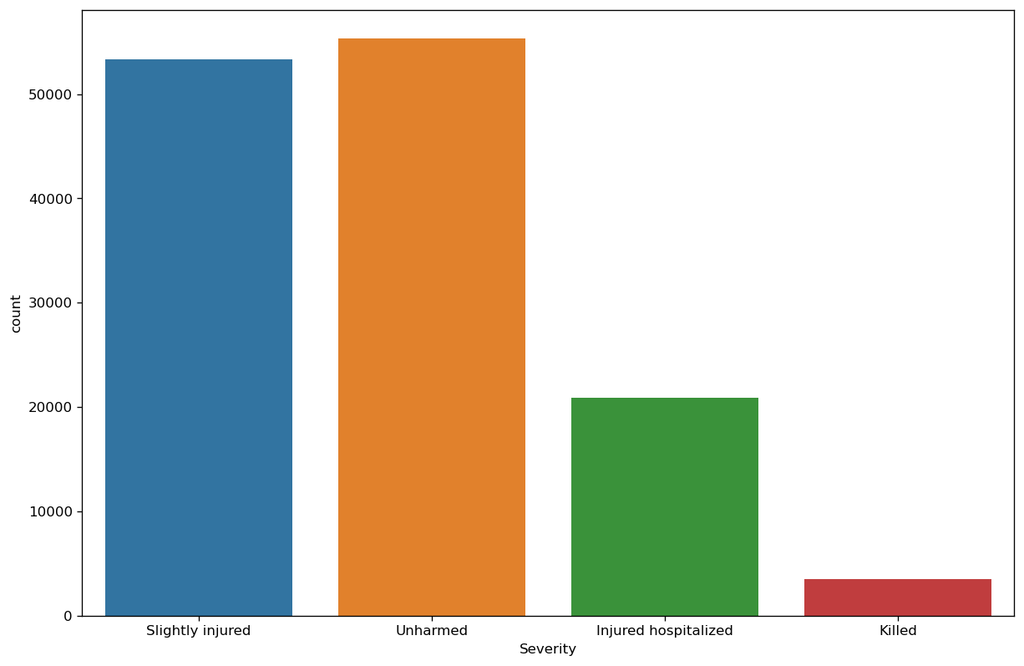

```python
sns.countplot(df['Severity'].map({1: 'Unharmed',
                                  2: 'Killed',
                                  3: 'Injured hospitalized',
                                  4: 'Slightly injured'
                                  }))
```

```python
df.select_dtypes(include=['float64', 'int64']).columns
```

```
Index(['Day', 'Month', 'Year', 'Time', 'Light', 'Location', 'int', 'atm',
       'col', 'lat', 'long', 'road_cat', 'road_index1', 'traffic_regime',
       'traffic_lanes', 'reserved_lane', 'prof', 'upstream_terminal',
       'distance_to_upstream', 'plan', 'central_reservation_width',
       'roadwidth_vehicles', 'surf', 'infra', 'situ', 'speed_limit', 'place',
       'User_category', 'Severity', 'Gender_driver', 'DOB_driver',
       'Reason_for_travel', 'Safety_equip_1', 'Safety_equip_2',
       'Safety_equip_3', 'Ped_loc', 'Ped_acc', 'Flow_Direction',
       'Vehicle_category', 'Fix_Obst_st', 'Mov_Obst_st', 'Shock_pt',
       'Maneuver', 'motor', 'No.of_occupants'],
      dtype='object')
```

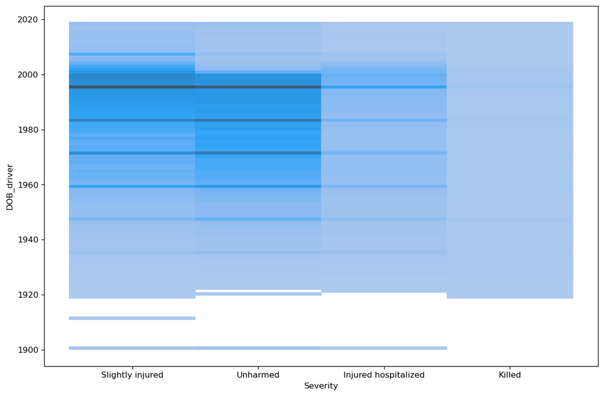

```python
sns.histplot(y=df["DOB_driver"], x=df["Severity"].map({1: 'Unharmed',
                                                       2: 'Killed',
                                                       3: 'Injured hospitalized',
                                                       4: 'Slightly injured'
                                                       }))
```

# Umgang mit fehlenden Werten

```python
# df = df.where(df != -1, np.nan)
```

```python
df_missing = pd.DataFrame(
    np.transpose(
        np.array(
                (df.columns, round(df.isna().sum()
                 /df.shape[0], 4)), dtype=object,)), columns=['features', 'missing_rate'])
df_missing
```

|  | features | missing_rate |
| --- | --- | --- |
| 0 | Day | 0.002 |
| 1 | Month | 0.002 |
| 2 | Year | 0.002 |
| 3 | Time | 0.002 |
| 4 | Light | 0.002 |
| 5 | Department | 0.002 |
| 6 | Municipality | 0.002 |
| 7 | Location | 0.002 |
| 8 | int | 0.002 |
| 9 | atm | 0.002 |
| 10 | col | 0.002 |
| 11 | adr | 0.0097 |
| 12 | lat | 0.002 |
| 13 | long | 0.002 |
| 14 | road_cat | 0.002 |
| 15 | route_num | 0.0464 |
| 16 | road_index1 | 0.1863 |
| 17 | road_index2 | 0.927 |
| 18 | traffic_regime | 0.0523 |
| 19 | traffic_lanes | 0.0125 |
| 20 | reserved_lane | 0.0127 |
| 21 | prof | 0.0022 |
| 22 | upstream_terminal | 0.1204 |
| 23 | distance_to_upstream | 0.1255 |
| 24 | plan | 0.0021 |
| 25 | central_reservation_width | 0.9965 |
| 26 | roadwidth_vehicles | 0.9938 |
| 27 | surf | 0.0023 |
| 28 | infra | 0.0027 |
| 29 | situ | 0.0037 |
| 30 | speed_limit | 0.0162 |
| 31 | Vehicle_No | 0 |
| 32 | place | 0 |
| 33 | User_category | 0 |
| 34 | Severity | 0 |
| 35 | Gender_driver | 0 |
| 36 | DOB_driver | 0 |
| 37 | Reason_for_travel | 0 |
| 38 | Safety_equip_1 | 0 |
| 39 | Safety_equip_2 | 0 |
| 40 | Safety_equip_3 | 0 |
| 41 | Ped_loc | 0 |
| 42 | Ped_act | 0 |
| 43 | Ped_acc | 0 |
| 44 | Flow_Direction | 0 |
| 45 | Vehicle_category | 0 |
| 46 | Fix_Obst_st | 0 |
| 47 | Mov_Obst_st | 0 |
| 48 | Shock_pt | 0 |
| 49 | Maneuver | 0 |
| 50 | motor | 0 |
| 51 | No.of_occupants | 0.9859 |

Bei den Umfallcharakteristika fehlen nur 0,2% der Werte. Diese Zeilen werden gelöscht. Außerdem werden die Features, bei denen mehr als 30% der Werte fehlen ebenfalls gelöscht.

```python
# df = df.loc[(df["Day"].notna()) & (df["surf"].notna()) & (df["plan"].notna()) & (df["prof"].notna())]
#df = df.drop(columns = ["road_index1", "road_index2", "upstream_terminal", "central_reservation_width", "roadwidth_vehicles", "No.of_occupants", "Year","Safety_equip_3"])
```

```python
df_missing = pd.DataFrame(
    np.transpose(
        np.array(
                (df.columns, round(df.isna().sum()
                 /df.shape[0], 4)), dtype=object,)), columns=['features', 'missing_rate'])
df_missing
```

|  | features | missing_rate |
| --- | --- | --- |
| 0 | Day | 0.002 |
| 1 | Month | 0.002 |
| 2 | Year | 0.002 |
| 3 | Time | 0.002 |
| 4 | Light | 0.002 |
| 5 | Department | 0.002 |
| 6 | Municipality | 0.002 |
| 7 | Location | 0.002 |
| 8 | int | 0.002 |
| 9 | atm | 0.002 |
| 10 | col | 0.002 |
| 11 | adr | 0.0097 |
| 12 | lat | 0.002 |
| 13 | long | 0.002 |
| 14 | road_cat | 0.002 |
| 15 | route_num | 0.0464 |
| 16 | road_index1 | 0.1863 |
| 17 | road_index2 | 0.927 |
| 18 | traffic_regime | 0.0523 |
| 19 | traffic_lanes | 0.0125 |
| 20 | reserved_lane | 0.0127 |
| 21 | prof | 0.0022 |
| 22 | upstream_terminal | 0.1204 |
| 23 | distance_to_upstream | 0.1255 |
| 24 | plan | 0.0021 |
| 25 | central_reservation_width | 0.9965 |
| 26 | roadwidth_vehicles | 0.9938 |
| 27 | surf | 0.0023 |
| 28 | infra | 0.0027 |
| 29 | situ | 0.0037 |
| 30 | speed_limit | 0.0162 |
| 31 | Vehicle_No | 0 |
| 32 | place | 0 |
| 33 | User_category | 0 |
| 34 | Severity | 0 |
| 35 | Gender_driver | 0 |
| 36 | DOB_driver | 0 |
| 37 | Reason_for_travel | 0 |
| 38 | Safety_equip_1 | 0 |
| 39 | Safety_equip_2 | 0 |
| 40 | Safety_equip_3 | 0 |
| 41 | Ped_loc | 0 |
| 42 | Ped_act | 0 |
| 43 | Ped_acc | 0 |
| 44 | Flow_Direction | 0 |
| 45 | Vehicle_category | 0 |
| 46 | Fix_Obst_st | 0 |
| 47 | Mov_Obst_st | 0 |
| 48 | Shock_pt | 0 |
| 49 | Maneuver | 0 |
| 50 | motor | 0 |
| 51 | No.of_occupants | 0.9859 |

# ----------------------------------------------------------------------------

```python
df["distance_to_upstream"].describe()
```

```
count    116286.000000
mean        199.610822
std         318.521151
min           0.000000
25%           0.000000
50%           0.000000
75%         399.000000
max        7000.000000
Name: distance_to_upstream, dtype: float64
```

```python
df["distance_to_upstream"].quantile(0.58) #58% aller Werte unter 1, 12% nan -> delete column
```

```
1.0
```

```python
df = df.drop(columns = ["road_index1", "road_index2", "upstream_terminal","distance_to_upstream", "central_reservation_width",
                        "roadwidth_vehicles", "No.of_occupants", "Year","Safety_equip_3"])
```

```python
df = df.loc[df["Day"].notna()] #fehlende Werte in diesen Spalten sind nicht sinnvoll aufzufüllen, deswegen Zeilen löschen
df = df.loc[df["prof"].notna()]
df = df.loc[df["plan"].notna()]
df = df.loc[df["surf"].notna()]
df = df.loc[df["adr"].notna()]
df = df.loc[df["route_num"].notna()]
df = df.loc[df["speed_limit"].notna()]
```

```python
############ab hier ersetzungen############
```

```python
df["traffic_regime"].unique() #Einbahn, normal -> wenn impute dann ersetzen mit 2.0, d.h. bidirektional
```

```
array([ 3.,  1.,  2., nan,  4.])
```

```python
df["traffic_regime"].value_counts() #meiste ist bedirektional, dann einbahnstraße, dann Feldweg
```

```
2.0    74322
1.0    22322
3.0    20901
4.0      814
Name: traffic_regime, dtype: int64
```

```python
df["traffic_regime"].median()
```

```
2.0
```

```python
df['traffic_regime'] = df['traffic_regime'].fillna(2.0) #impute with modus = median. später alle Spalten auf einmal
```

```python
df["traffic_regime"].value_counts()
```

```
2.0    80372
1.0    22322
3.0    20901
4.0      814
Name: traffic_regime, dtype: int64
```

```python
df["traffic_lanes"].unique()
```

```
array([10.,  2.,  8.,  5.,  3.,  4.,  6.,  1.,  7.,  0., nan,  9., 11.,
       12.])
```

```python
df["traffic_lanes"].value_counts() #most common: 2 lanes #impute with
```

```
2.0     72702
4.0     16748
1.0     11191
3.0     10584
6.0      4033
0.0      3039
5.0      2584
8.0      1337
7.0       531
10.0      416
9.0       287
11.0       94
12.0       75
Name: traffic_lanes, dtype: int64
```

```python
df['traffic_lanes'] = df['traffic_lanes'].fillna(2) #impute with modus = mediann = 2
```

```python
df["traffic_lanes"].value_counts()
```

```
2.0     73490
4.0     16748
1.0     11191
3.0     10584
6.0      4033
0.0      3039
5.0      2584
8.0      1337
7.0       531
10.0      416
9.0       287
11.0       94
12.0       75
Name: traffic_lanes, dtype: int64
```

```python
df["reserved_lane"].unique()
```

```
array([ 0.,  1.,  3.,  2., nan])
```

```python
df["reserved_lane"].value_counts() #most common: 0 means not applicable #impute with 0 = modus = mean = most unmarked
```

```
0.0    114076
1.0      3892
3.0      3757
2.0      1839
Name: reserved_lane, dtype: int64
```

```python
df['reserved_lane'] = df['reserved_lane'].fillna(0) #impute with modus = mediann = 0
```

```python
df["infra"].unique()
```

```
array([ 2.,  0.,  9.,  1.,  5.,  4.,  6.,  3.,  8., nan,  7.])
```

```python
df["infra"].value_counts() #most common: 0 means no infrastructure #impute with 0 = modus = mean = most unmarked
```

```
0.0    103125
5.0      7502
9.0      4568
2.0      2584
3.0      2020
1.0      1781
8.0      1099
6.0      1039
4.0       518
7.0        99
Name: infra, dtype: int64
```

```python
df['infra'] = df['infra'].fillna(0) #impute with modus = median = 0, most unmarked
```

```python
df["infra"].value_counts()
```

```
0.0    103199
5.0      7502
9.0      4568
2.0      2584
3.0      2020
1.0      1781
8.0      1099
6.0      1039
4.0       518
7.0        99
Name: infra, dtype: int64
```

```python
df["situ"].value_counts() #most common: 1 means no special situation #impute with 1 = modus = mean = most unmarked
```

```
1.0    111037
3.0      6789
2.0      1953
8.0      1589
4.0       988
5.0       940
6.0       903
Name: situ, dtype: int64
```

```python
df['situ'] = df['situ'].fillna(1)
```

```python
df["situ"].value_counts()
```

```
1.0    111247
3.0      6789
2.0      1953
8.0      1589
4.0       988
5.0       940
6.0       903
Name: situ, dtype: int64
```

```python
df['speed_limit'].value_counts() #alles unter 7 wird zu 7, alles über 500 wird zu 500 und heißt kein limit
#fehlende werte löschen (1,4% der Daten)
```

```
50.0     68444
80.0     19217
70.0      9694
90.0      8737
30.0      7667
110.0     5624
130.0     3571
60.0       462
20.0       286
10.0       210
40.0       109
15.0        68
5.0         56
45.0        46
2.0         44
500.0       35
100.0       30
1.0         23
25.0        20
6.0         14
3.0         14
35.0         9
4.0          7
42.0         4
700.0        4
65.0         4
7.0          2
120.0        2
12.0         2
0.0          2
600.0        1
800.0        1
Name: speed_limit, dtype: int64
```

```python
df.loc[(df["speed_limit"]  <7), "speed_limit"]= 7
df.loc[(df["speed_limit"]  >300), "speed_limit"]= 300
```

```python
df['speed_limit'].value_counts()
```

```
50.0     68444
80.0     19217
70.0      9694
90.0      8737
30.0      7667
110.0     5624
130.0     3571
60.0       462
20.0       286
10.0       210
7.0        162
40.0       109
15.0        68
45.0        46
300.0       41
100.0       30
25.0        20
35.0         9
65.0         4
42.0         4
120.0        2
12.0         2
Name: speed_limit, dtype: int64
```

```python
####################################################################
```

```python
df.info()
```

```
<class 'pandas.core.frame.DataFrame'>
Index: 124409 entries, 201900000001 to 201900058840
Data columns (total 43 columns):
 #   Column             Non-Null Count   Dtype
---  ------             --------------   -----
 0   Day                124409 non-null  float64
 1   Month              124409 non-null  float64
 2   Time               124409 non-null  float64
 3   Light              124409 non-null  float64
 4   Department         124409 non-null  object
 5   Municipality       124409 non-null  object
 6   Location           124409 non-null  float64
 7   int                124409 non-null  float64
 8   atm                124409 non-null  float64
 9   col                124409 non-null  float64
```

[output cut: 35 more lines]

```python
df["Ped_act"].unique()
```

```
array(['-1', '0', '3', '2', '1', 'B', '4', '9', '5', 'A', '8', '6', '7'],
      dtype=object)
```

```python
df["Ped_act"].value_counts()
```

```
0     88482
-1    25806
3      7550
1       617
9       580
5       401
B       398
2       277
4       152
A        97
6        22
7        17
8        10
Name: Ped_act, dtype: int64
```

```python
df = df[df["Ped_act"] != '7']
df = df[df["Ped_act"] != '8']
df.loc[(df["Ped_act"] =='A'), "Ped_act"]= 7
df.loc[(df["Ped_act"] =='B'), "Ped_act"]= 8
```

```python
df["Ped_act"]=df["Ped_act"].astype(int)
```

```python
#####Coding sometimes starts with -1 (unknown), sometimes with 0 (not assigned) or 1 (proper category)
```

```python
df.iloc[:,30:].describe()
#kodierung mit -1 bei reason for travel (-1 und 0 not assigned)
# safety equip (-1: unbekannt, 8: not determinable, 9: others)
# safety equip2 (-1: unbekannt, 8: not determinable, 9: others)
# ped_loc (-1: unbekannt, 9 inconnu)
# ped_act (-1: unbekannt, 0 nicht zugewiesen oder ohne objekt, 9: others)
#ped_acc (-1: unbekannt)
#flow direction (-1: not assigned, 0:unknown)
# fixed obst (-1: unknown, 0: no object)
#mov_obst (-1: not assigned, 0: none, 9: other)
#shock_pt (-1: not assigned, 0:none )
#maneuver (-1: not assigned, 0: unknown, 26: other)
#motor (-1: not assigned, 0:unknown, 6: other)
```

|  | Reason_for_travel | Safety_equip_1 | Safety_equip_2 | Ped_loc | Ped_act | Ped_acc | Flow_Direction | Vehicle_category | Fix_Obst_st | Mov_Obst_st | Shock_pt | Maneuver | motor |
| --- | --- | --- | --- | --- | --- | --- | --- | --- | --- | --- | --- | --- | --- |
| count | 124382.000000 | 124382.000000 | 124382.000000 | 124382.000000 | 124382.000000 | 124382.000000 | 124382.000000 | 124382.000000 | 124382.000000 | 124382.000000 | 124382.000000 | 124382.000000 | 124382.000000 |
| mean | 3.206726 | 2.201034 | 1.536155 | -0.133918 | 0.079135 | -0.815592 | 1.548600 | 12.266325 | 1.095786 | 1.553271 | 2.923711 | 7.241289 | 1.147996 |
| std | 2.673199 | 2.480861 | 3.306909 | 1.233271 | 1.220090 | 0.639251 | 0.807621 | 12.309099 | 3.227583 | 1.067302 | 2.390162 | 8.121718 | 1.042005 |
| min | -1.000000 | -1.000000 | -1.000000 | -1.000000 | -1.000000 | -1.000000 | -1.000000 | 0.000000 | -1.000000 | -1.000000 | -1.000000 | -1.000000 | -1.000000 |
| 25% | 0.000000 | 1.000000 | -1.000000 | -1.000000 | 0.000000 | -1.000000 | 1.000000 | 7.000000 | 0.000000 | 1.000000 | 1.000000 | 1.000000 | 1.000000 |
| 50% | 4.000000 | 1.000000 | 0.000000 | 0.000000 | 0.000000 | -1.000000 | 1.000000 | 7.000000 | 0.000000 | 2.000000 | 2.000000 | 2.000000 | 1.000000 |
| 75% | 5.000000 | 2.000000 | 4.000000 | 0.000000 | 0.000000 | -1.000000 | 2.000000 | 10.000000 | 0.000000 | 2.000000 | 4.000000 | 15.000000 | 1.000000 |
| max | 9.000000 | 9.000000 | 9.000000 | 9.000000 | 9.000000 | 3.000000 | 3.000000 | 99.000000 | 17.000000 | 9.000000 | 9.000000 | 26.000000 | 6.000000 |

```python
#change -1 (not assigned) values where it makes sense (mostly to unknown)
df.loc[(df["Reason_for_travel"] == -1), "Reason_for_travel"]= 0 #both were the same
df.loc[(df["Safety_equip_1"] == -1), "Safety_equip_1"]= 8 #change to not deterrminable
df.loc[(df["Safety_equip_2"] == -1), "Safety_equip_2"]= 8 #change to not deterrminable
df.loc[(df["Ped_loc"] == -1), "Ped_loc"]= 9 #9 was also unknown
#df.loc[(df["Ped_acc"] == -1), "Ped_acc"]= 0 #just changed the value, value 0 did not exist before
df.loc[(df["Flow_Direction"] == -1), "Flow_Direction"]= 0 # changed to unknown
df.loc[(df["Maneuver"] == -1), "Maneuver"]= 0 # changed to unknown
df.loc[(df["motor"] == -1), "motor"]= 0 # changed to unknown
```

```python
df["Ped_loc"].unique()
```

```
array([9, 0, 2, 3, 1, 5, 4, 8, 6, 7], dtype=int64)
```

```python
df['situ'] = df['situ'].fillna(1.0) #impute with modus = median = 0, most unmarked
```

```python
###############ab hier encoding der string variablen#################
```

```python
from sklearn.preprocessing import LabelEncoder
def encoding(df):
    label = LabelEncoder()
    for c in df.select_dtypes("object"):
        df[c]=df[c].astype(str)
        df[c]=label.fit_transform(df[c])
    return df

stringcolumns = df.select_dtypes("object")

df = encoding(df)
```

```python
df.info()
```

```
<class 'pandas.core.frame.DataFrame'>
Index: 124382 entries, 201900000001 to 201900058840
Data columns (total 43 columns):
 #   Column             Non-Null Count   Dtype
---  ------             --------------   -----
 0   Day                124382 non-null  float64
 1   Month              124382 non-null  float64
 2   Time               124382 non-null  float64
 3   Light              124382 non-null  float64
 4   Department         124382 non-null  int32
 5   Municipality       124382 non-null  int32
 6   Location           124382 non-null  float64
 7   int                124382 non-null  float64
 8   atm                124382 non-null  float64
 9   col                124382 non-null  float64
```

[output cut: 35 more lines]

# ----------------------------------------------------------------------------

```python
from sklearn.naive_bayes import GaussianNB
from sklearn.neighbors import KNeighborsClassifier
from sklearn.ensemble import RandomForestClassifier
```

```python
from sklearn.decomposition import PCA
from sklearn.preprocessing import StandardScaler
```

```python
from sklearn.model_selection import train_test_split
X_train, X_test, y_train, y_test = train_test_split(X, y, test_size=0.33, random_state=42)
```

```python
from sklearn.model_selection import GridSearchCV
```

# Ab hier nur mit Autobahndaten

# SVC

```python
from sklearn.svm import SVC
```

```python
svc = SVC().fit(X_train, y_train)
```

```python
svc.score(X_train, y_train)
```

```
0.4611692425842373
```

```python
svc.score(X_test, y_test)
```

```
0.46200311769290725
```

```python
params_svc = {
    'C': [100, 1000, 10000],
}
```

```python
%%time
gsc_scv = GridSearchCV(SVC(), params_svc)
gsc_scv.fit(X_train, y_train)
```

```
Wall time: 14min 1s
```

```
GridSearchCV(estimator=SVC(), param_grid={'C': [100, 1000, 10000]})
```

```python
gsc_scv.best_params_
```

```
{'C': 10000}
```

```python
bpsvc = SVC(**gsc_scv.best_params_)
```

```python
bpsvc.fit(X_train, y_train)
```

```
SVC(C=10000)
```

```python
bpsvc.score(X_test, y_test)
```

```
0.46200311769290725
```

```python
bpsvc.score(X_train, y_train)
```

```
0.4695209753287895
```

# Ausgabe für Abgabe

```python
gnb = GaussianNB()
knc = KNeighborsClassifier()
rfc = RandomForestClassifier()

clfs = [gnb, knc, rfc]
```

Im Folgenden beschränken wir uns auf die Unfälle auf Autobahnen:

```python
df_highway = df.loc[df["road_cat"] == 1]
```

```python
X, y = df_highway.drop(columns="Severity"), df_highway["Severity"]
```

```python
PCA().fit(X).explained_variance_ratio_
```

```
array([8.69409227e-01, 1.30590771e-01, 1.52486337e-09, 5.23687011e-10,
       1.11151583e-11, 1.92704866e-14, 1.10132462e-14, 3.23020765e-15,
       2.86979977e-15, 1.92917731e-15, 7.41563339e-16, 4.52985603e-16,
       3.30699243e-16, 3.24895617e-16, 2.50097999e-16, 2.15056014e-16,
       1.69139852e-16, 1.20743186e-16, 1.03522552e-16, 9.66597049e-17,
       9.19598599e-17, 8.89943543e-17, 7.99342894e-17, 7.59832596e-17,
       6.36904650e-17, 5.46287587e-17, 3.15599462e-17, 2.56379220e-17,
       2.20568259e-17, 2.15109151e-17, 1.52586510e-17, 1.41127038e-17,
       1.19035316e-17, 1.03884990e-17, 9.40638517e-18, 8.18783298e-18,
       7.85153847e-18, 3.43103507e-18, 2.21238601e-18, 8.39369788e-19,
       6.87379381e-19, 8.66202021e-33])
```

Die ersten zwei Komponenten erklären bereits 99% der Varianz, wir können uns also auf diese beiden beschränken:

```python
X = PCA(n_components=2).fit(X).transform(X)
```

```python
X_train, X_test, y_train, y_test = train_test_split(X, y, test_size=0.33, random_state=42)
```

```python
%%time
scores = []
for clf in clfs:
    clf.fit(X_train, y_train)
    scores.append((str(clf), clf.score(X_train, y_train), clf.score(X_test, y_test)))
```

```
Wall time: 3.96 s
```

```python
scores
```

```
[('GaussianNB()', 0.45838533166938655, 0.4618082618862042),
 ('KNeighborsClassifier()', 0.630795814533935, 0.4520654715510522),
 ('RandomForestClassifier()', 0.7253527887107613, 0.41095089633671084)]
```

## Mit Stratified

```python
from sklearn.model_selection import StratifiedShuffleSplit

sss = StratifiedShuffleSplit(n_splits=2, test_size=0.33, random_state=0)
X, y = df_highway.drop(columns="Severity").to_numpy(), df_highway["Severity"].to_numpy()

train_index, test_index = next(sss.split(X, y))

X_train, X_test = X[train_index], X[test_index]
y_train, y_test = y[train_index], y[test_index]
```

```python
%%time
scores = []
for clf in clfs:
    clf.fit(X_train, y_train)
    scores.append((str(clf), clf.score(X_train, y_train), clf.score(X_test, y_test)))
```

```
Wall time: 7.96 s
```

```python
scores
```

```
[('GaussianNB()', 0.4535854852644715, 0.4553780202650039),
 ('KNeighborsClassifier()', 0.6371316117884228, 0.45654715510522215),
 ('RandomForestClassifier()', 0.9998080061438034, 0.6718628215120811)]
```

## Crossvalidation

```python
from sklearn.model_selection import cross_validate
cv_results = []

for clf in clfs:
    cv_results.append((str(clf), cross_validate(clf, X_test, y_test, cv=5)["test_score"].mean() ))
```

```python
cv_results
```

```
[('GaussianNB()', 0.4553777064103513),
 ('KNeighborsClassifier()', 0.4694076693410471),
 ('RandomForestClassifier()', 0.6533518964564934)]
```

Die Crossvaldidation zeigt, dass die oben berechneten Scores stimmen.

# GridSearch

```python
# gridsearch_scores:
gs_scores = []
```

## RandomForest

```python
params_rf = {
    'n_estimators': [10, 100, 250, 500],
    'criterion': ['gini', 'entropy'],
    'min_samples_split': [2, 6, 12],
    'n_jobs': [-1],
}
```

```python
%%time
gsc_rf = GridSearchCV(RandomForestClassifier(), params_rf)
gsc_rf.fit(X_train, y_train)
```

```
Wall time: 7min 51s
```

```
GridSearchCV(estimator=RandomForestClassifier(),
             param_grid={'criterion': ['gini', 'entropy'],
                         'min_samples_split': [2, 6, 12],
                         'n_estimators': [10, 100, 250, 500], 'n_jobs': [-1]})
```

```python
gsc_rf.best_params_
```

```
{'criterion': 'gini',
 'min_samples_split': 12,
 'n_estimators': 500,
 'n_jobs': -1}
```

```python
bprfc = RandomForestClassifier(**gsc_rf.best_params_)
```

```python
bprfc.fit(X_train, y_train)
```

```
RandomForestClassifier(min_samples_split=12, n_estimators=500, n_jobs=-1)
```

```python
bprfc.score(X_train, y_train)
```

```
0.9076509551694346
```

```python
bprfc.score(X_test, y_test)
```

```
0.6769290724863601
```

```python
gs_scores.append((bprfc.score(X_train, y_train), bprfc.score(X_test, y_test)))
```

## KNN

```python
params_kn = {
    'n_neighbors': [3, 5, 10],
    'weights': ['uniform', 'distance'],
    'algorithm': ['auto', 'ball_tree'],
    'p': [1, 2, 10],
    'n_jobs': [-1],
}
```

```python
%%time
gsc_kn = GridSearchCV(KNeighborsClassifier(), params_kn)
gsc_kn.fit(X_train, y_train)
```

```
Wall time: 2min 18s
```

```
GridSearchCV(estimator=KNeighborsClassifier(),
             param_grid={'algorithm': ['auto', 'ball_tree'], 'n_jobs': [-1],
                         'n_neighbors': [3, 5, 10], 'p': [1, 2, 10],
                         'weights': ['uniform', 'distance']})
```

```python
gsc_kn.best_params_
```

```
{'algorithm': 'ball_tree',
 'n_jobs': -1,
 'n_neighbors': 10,
 'p': 2,
 'weights': 'uniform'}
```

```python
bpknc = KNeighborsClassifier(**gsc_kn.best_params_)
```

```python
bpknc.fit(X_train, y_train)
```

```
KNeighborsClassifier(algorithm='ball_tree', n_jobs=-1, n_neighbors=10)
```

```python
bpknc.score(X_train, y_train)
```

```
0.5834693289814726
```

```python
bpknc.score(X_test, y_test)
```

```
0.4696024941543258
```

```python
gs_scores.append((bpknc.score(X_train, y_train), bpknc.score(X_test, y_test)))
```

```python
gs_scores
```

```
[(0.9076509551694346, 0.6769290724863601),
 (0.5834693289814726, 0.4696024941543258)]
```

# VotingClassifier

```python
from sklearn.ensemble import VotingClassifier
```

```python
clfs, clfs_names = [GaussianNB(), bpknc, bprfc], ["GNB", "KNN", "RFC"]
```

```python
list(zip(clfs_names, clfs))
```

```
[('GNB', GaussianNB()),
 ('KNN',
  KNeighborsClassifier(algorithm='ball_tree', n_jobs=-1, n_neighbors=10)),
 ('RFC',
  RandomForestClassifier(min_samples_split=12, n_estimators=500, n_jobs=-1))]
```

```python
eclf1 = VotingClassifier(estimators=list(zip(clfs_names, clfs)), voting='hard')
```

```python
eclf1.fit(X_train, y_train)
```

```
VotingClassifier(estimators=[('GNB', GaussianNB()),
                             ('KNN',
                              KNeighborsClassifier(algorithm='ball_tree',
                                                   n_jobs=-1, n_neighbors=10)),
                             ('RFC',
                              RandomForestClassifier(min_samples_split=12,
                                                     n_estimators=500,
                                                     n_jobs=-1))])
```

```python
eclf1.score(X_train, y_train), eclf1.score(X_test, y_test)
```

```
(0.6794662570797735, 0.5543647700701481)
```

```python
eclf2 = VotingClassifier(estimators=list(zip(clfs_names, clfs)), voting='soft')
```

```python
eclf2.fit(X_train, y_train)
```

```
VotingClassifier(estimators=[('GNB', GaussianNB()),
                             ('KNN',
                              KNeighborsClassifier(algorithm='ball_tree',
                                                   n_jobs=-1, n_neighbors=10)),
                             ('RFC',
                              RandomForestClassifier(min_samples_split=12,
                                                     n_estimators=500,
                                                     n_jobs=-1))],
                 voting='soft')
```

```python
eclf2.score(X_train, y_train), eclf2.score(X_test, y_test)
```

```
(0.8087741192281847, 0.6231488698363211)
```

## Versuch mit SVC

```python
clfs.append(SVC(C=1, probability=True))
clfs_names.append("SVC")
```

```python
eclf3 = VotingClassifier(estimators=list(zip(clfs_names, clfs)), voting='soft')
```

```python
eclf3.fit(X_train, y_train)
```

```
VotingClassifier(estimators=[('GNB', GaussianNB()),
                             ('KNN',
                              KNeighborsClassifier(algorithm='ball_tree',
                                                   n_jobs=-1, n_neighbors=10)),
                             ('RFC',
                              RandomForestClassifier(min_samples_split=12,
                                                     n_estimators=500,
                                                     n_jobs=-1)),
                             ('SVC', SVC(C=1, probability=True))],
                 voting='soft')
```

```python
eclf3.score(X_train, y_train), eclf3.score(X_test, y_test)
```

```
(0.8014783526927138, 0.6249025720966485)
```

## gewichtes Voting

```python
clfs, clfs_names = [GaussianNB(), bpknc, bprfc], ["GNB", "KNN", "RFC"]
```

```python
eclf4 = VotingClassifier(estimators=list(zip(clfs_names, clfs)), voting='soft', weights=[0.5, 0.5, 1.5])
```

```python
eclf4.fit(X_train, y_train)
```

```
VotingClassifier(estimators=[('GNB', GaussianNB()),
                             ('KNN',
                              KNeighborsClassifier(algorithm='ball_tree',
                                                   n_jobs=-1, n_neighbors=10)),
                             ('RFC',
                              RandomForestClassifier(min_samples_split=12,
                                                     n_estimators=500,
                                                     n_jobs=-1))],
                 voting='soft', weights=[0.5, 0.5, 1.5])
```

```python
eclf4.score(X_train, y_train), eclf4.score(X_test, y_test)
```

```
(0.875875971968897, 0.661340607950117)
```